# 213070011_EE679_CA2

**EE 679, Computing Assignment 2**

**Roll No. 213070011**

**Name - Ayushi Thawait**

**Solution 1**

Importing the Wave file and applying pre-emphasis to the signal.

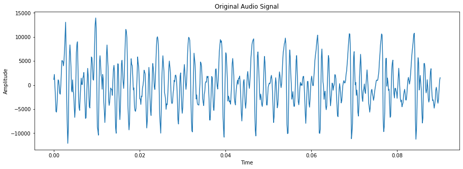

```python
import numpy as np
import os
from google.colab import drive
import matplotlib.pyplot as plt
import IPython.display as ipd
import librosa
from scipy import signal
from scipy.fftpack import fft
from numpy import pi, cos, log10
from scipy.fftpack import fft, fftshift
from scipy.io import wavfile
from scipy.fft import fftfreq

fs ,signal1 = wavfile.read('/content/aa.wav')
Time = np.linspace(0, len(signal1) / fs, num=len(signal1))

plt.figure(1,figsize = (15,5))
plt.plot(Time,signal1)
plt.title('Original Audio Signal')
plt.xlabel('Time')
plt.ylabel('Amplitude')
```

**Designing Pre-Emphasis Filter**

The pre-emphesis filter can be applied to a signal x using the first order filter in the following equation in time domain:

y(t)=x(t)−αx(t−1)

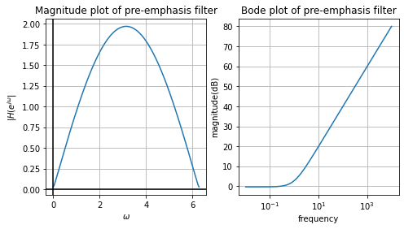

```python
from scipy import signal
def filter(w):
  Z=np.exp(1j*w)
  '''Writing given transfer function'''
  H=1-0.97*Z**(-1)
  return H

w=np.arange(0,2*np.pi,0.01)
magnitude=np.abs(filter(w))
phase=np.angle(filter(w))
figure = plt.figure(figsize = [12,4])
figure.add_subplot(1,3,1)
plt.plot(w,magnitude)
plt.title("Magnitude plot of pre-emphasis filter")
plt.xlabel("$\omega$")
plt.ylabel("$|H(e^{j\omega}|$")
plt.axvline(color = "black")
plt.axhline(color = "black")
plt.grid()
"""Plotting bode plot for pre-emphasis filter"""
p_emph=[1,-0.97]
sys = signal.TransferFunction(p_emph,[1])
w, mag, phase = signal.bode(sys)
figure.add_subplot(1,3,2)
plt.semilogx(w, mag)    # Bode magnitude plot
plt.title('Bode plot of pre-emphasis filter')
plt.xlabel('frequency')
plt.ylabel('magnitude(dB)')
plt.grid()
w=np.arange(0,2*np.pi,0.01)
```

pre-emphesis filter on signal to amplify the high frequencies. A pre-emphesis filter is useful in several ways: - balance frequency spectrum since high frequencies usually have smaller magnitudes compared to lower frequencies - avoid numerical problems during fourier operation - Might also improve the signal to Noise Ratio (SNR)

Applying Pre-emphasis Filter to input audio signal

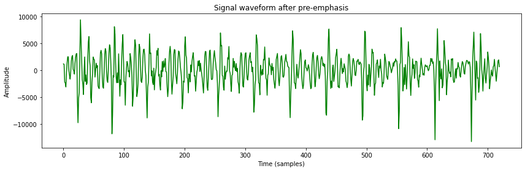

```python
fs ,signal1 = wavfile.read('/content/aa.wav')
pre_emphasis = 0.97
emphasized_signal = np.append(signal1[0], signal1[1:] - pre_emphasis * signal1[:-1])

plt.figure(figsize=(12, 4))
plt.plot(emphasized_signal, color='green')
plt.title('Signal waveform after pre-emphasis')
plt.xlabel('Time (samples)')
plt.ylabel('Amplitude')
plt.tight_layout()
plt.show()
```

Time Domain Plot for Pre-emphasised Signal,fromm the time domain plot it is not clearly visible that high freuency signal is boosted.So, we will see that in below frequency domain plot.

**Solution 2** plotting the narrowband magnitude spectrum slice using a Hamming window of duration = 30 ms on a segment near the centre of the given audio file.

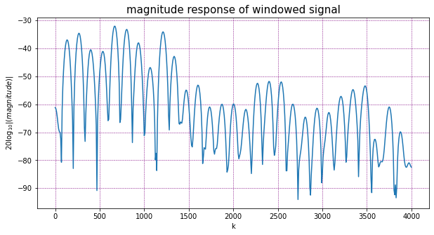

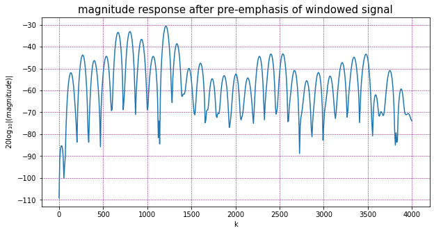

```python
from scipy import signal

fs ,signal1 = wavfile.read('/content/aa.wav')

def dft(x,w,N,M):

  """ Here we give window and input sound signal along with dft
  length and window length as input and we get windowed signal as output"""
  hn=(N//2)+1
  hm1=(np.size(w)+1)//2
  hm2=np.size(w)//2
  fftbuffer=np.zeros(N)        # Initializing zero buffer of dft length
  w=w/np.sum(w)                # normalizing analysis window
  """choosing the input frame from the middle of
   input sequence"""
  f=400+M
  x=x[400:f]
  mul=x*w                      # windowing the input sequence
  """ placing the windowed sequence in the zero buffer"""
  fftbuffer[:hm1]=mul[hm2:]
  fftbuffer[-hm2:]=mul[:hm2]
  X=fft(fftbuffer)
  absX=abs(X[:hn])            # taking absolute value of output magnitude
  absX[absX<np.finfo(float).eps]=np.finfo(float).eps   # checking for zero values in magnitude before taking log
  # mag=-1*20*np.log10(absX)
  mag=20*np.log10(absX)
  return mag,mul



"""Windowed output for window of length 30 msec"""
N=1024
Fs=8000
duration=0.03
M=int(duration*Fs)
hamming_window=signal.get_window('hamming',M)
x,time_x=dft(signal1,hamming_window,N,M)
emph_x,time_x=dft(emphasized_signal,hamming_window,N,M)

plt.figure(1,figsize=(10,5))
plt.title("magnitude response of windowed signal",fontsize = 15)
plt.plot(np.arange(0,(Fs/2)+1,Fs/float(N)),x-1.5*max(x))
plt.xlabel('k')
plt.ylabel('$20\log_{10}|(magnitude)|$')
plt.grid(color='purple',linestyle='--',linewidth=0.5)

plt.figure(2,figsize=(10,5))
plt.title("magnitude response after pre-emphasis of windowed signal",fontsize = 15)
plt.plot(np.arange(0,(Fs/2)+1,Fs/float(N)),emph_x-1.5*max(emph_x))
plt.xlabel('k')
plt.ylabel('$20\log_{10}|(magnitude)|$')
plt.grid(color='purple',linestyle='--',linewidth=0.5)
```

From the above plot, we can clearly compare and see that after pre-emphasis high frequency components are boosted.

**Solution 3**

computing the autocorrelation coefficients required for LPC calculation at various p = 2,4,6,8,10. and using the Levinson-Durbin recursion and Plotting error signal energy (i.e. square of gain) vs p.

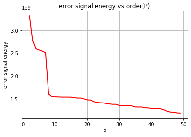

```python
#Defining Levinson-Durbin recursion function
def lpc(y, m):
    """Return Auto-correlation coefficients, error and m linear
    predictive coefficients for sequence y using Levinson-Durbin prediction algorithm"""
    #step 1: compute autoregression coefficients R_0, ..., R_m
    R = [y.dot(y)]
    if R[0] == 0:
        return [1] + [0] * (m-2) + [-1]
    else:
        for i in range(1, m + 1):
            r = y[i:].dot(y[:-i])
            R.append(r)
        R = np.array(R)
    #step 2: compute LP coeff's A_0,A_1....., A_m
        A = np.array([1, -R[1] / R[0]])
        E = R[0] + R[1] * A[1]
        for k in range(1, m):
            if (E == 0):
                E = 10e-17
            alpha = - A[:k+1].dot(R[k+1:0:-1]) / E
            A = np.hstack([A,0])
            A = A + alpha * A[::-1]
            E *= (1 - alpha**2)
        return A,E,R
error=[]
order=np.arange(2,50,1)
for i in range(0,48):
  a,e,r=lpc(emphasized_signal,order[i])
  error.append(e)
  """Plotting the error signal energy vs order of filter"""
plt.plot(order,error, color='red', linestyle='solid',
     linewidth=2, markersize=12)
plt.title('error signal energy vs order(P)')
plt.xlabel('P')
plt.ylabel('error signal energy')
plt.grid(True)
```

From the above plot of error energy signal Vs order(p), we can see that as the Order p (i.e no. of pole) increases the error reduces.Hence this plot verifies the theory of the Levinson-Durbin recursion that as order of filter increases the Error signal energy decreases as accuracy of predicted envelope to match the original envelope increases and it tries to match not only the peaks but also the vallies.

Also nearly at p = 8 the error reduces greatly therefore p=8 can be used as optimal order for analysis.

Calculating autocorrelation coefficients required for LPC calculation at various p = 2,4,6,8,10.

```python
#Calculating autocorrelation coefficients required for LPC calculation at various p = 2,4,6,8,10.

order=2
a1,e1,r1=lpc(emphasized_signal,order)
print( "Coefficient of A(z) filter for p = 2")
print( 'a1  is '+ str(a1))
print( 'e1  is '+ str(e1))
print( 'r1  is  '+ str(r1))

order=4
a2,e2,r2=lpc(emphasized_signal,order)
print( 'Coefficient of A(z) filter for p = 4')
print( 'a2  is '+ str(a2))
print( 'e2  is '+ str(e2))
print( 'r2  is '+ str(r2))

order=6
a3,e3,r3=lpc(emphasized_signal,order)
print( 'Coefficient of A(z) filter for p = 6')
print( 'a3  is '+ str(a3))
print( 'e3  is '+ str(e3))
print( 'r3  is '+ str(r3))

order=8
a4,e4,r4=lpc(emphasized_signal,order)
print( 'Coefficient of A(z) filter for p = 8')
print( 'a4  is '+ str(a4))
print( 'e4  is '+ str(e4))
print( 'r4  is '+ str(r4))

order=10
a5,e5,r5=lpc(emphasized_signal,order)
print( 'Coefficient of A(z) filter for p = 10')
print( 'a5  is '+ str(a5))
print( 'e5  is '+ str(e5))
print( 'r5  is '+ str(r5))
```

```
Coefficient of A(z) filter for p = 2
a1  is [ 1.         -0.8299613   0.43788414]
e1  is 3308366646.245177
r1  is  [6.13832356e+09 3.54310261e+09 2.52763548e+08]
Coefficient of A(z) filter for p = 4
a2  is [ 1.         -0.55132863  0.12858881  0.23923123  0.25205298]
e2  is 2592880345.038518
r2  is [ 6.13832356e+09  3.54310261e+09  2.52763548e+08 -2.67777587e+09
 -3.90364062e+09]
Coefficient of A(z) filter for p = 6
a3  is [ 1.         -0.58751574  0.13607125  0.24950202  0.31896278 -0.16144397
  0.10332114]
e3  is 2538602149.2079463
r3  is [ 6.13832356e+09  3.54310261e+09  2.52763548e+08 -2.67777587e+09
 -3.90364062e+09 -2.49734693e+09 -4.10775032e+08]
Coefficient of A(z) filter for p = 8
a4  is [ 1.         -0.5075892   0.13952073  0.19840199  0.55538341  0.025203
  0.10692852 -0.23096848  0.59885717]
e4  is 1607087943.8186216
r4  is [ 6.13832356e+09  3.54310261e+09  2.52763548e+08 -2.67777587e+09
 -3.90364062e+09 -2.49734693e+09 -4.10775032e+08  1.31232682e+09
  5.69756674e+08]
Coefficient of A(z) filter for p = 10
a5  is [ 1.         -0.60269868  0.13202645  0.1973542   0.54577675 -0.06956656
  0.03197358 -0.26886119  0.67745195 -0.13643513 -0.07115696]
e5  is 1547010014.0855148
r5  is [ 6.13832356e+09  3.54310261e+09  2.52763548e+08 -2.67777587e+09
 -3.90364062e+09 -2.49734693e+09 -4.10775032e+08  1.31232682e+09
  5.69756674e+08  1.85522983e+08 -1.81257507e+07]
```

**Solution 4**

Plotting pole-zero plots of the estimated all-pole filter for p=6,10

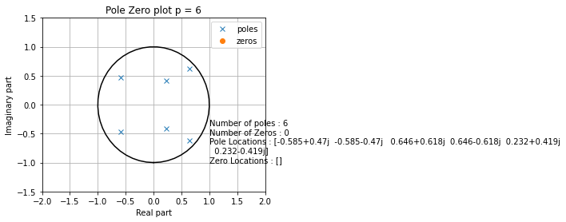

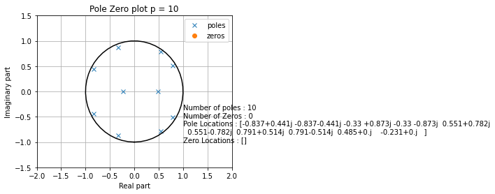

```python
from scipy.signal import tf2zpk
def PoleZeroPlot(b, a,plots=True):
  (zeros,poles,gain) = tf2zpk(b, a)
  angle = np.linspace(-np.pi,np.pi,50)
  cirx = np.sin(angle)
  ciry = np.cos(angle)
  if plots:
    plt.figure()
    plt.plot(poles.real, poles.imag, 'x', zeros.real, zeros.imag, 'o', cirx,ciry, 'k-')
    plt.xlim((-2, 2))
    plt.xlabel('Real part')
    plt.ylim((-1.5, 1.5))
    plt.ylabel('Imaginary part')
    plt.title("Pole Zero plot p = 6")
    plt.legend(["poles","zeros"])
    text = "Number of poles : {0} \nNumber of Zeros : {1} \nPole Locations : {2} \nZero Locations : {3}".format(len(poles),len(zeros),np.round(poles,3),np.round(zeros,3))
    plt.text(1,-1,text)
    plt.gcf().set_figwidth(5)
    plt.grid()
  return (zeros,poles,gain)


order= 2
a1,e1,r1=lpc(emphasized_signal,order)
z1,p1,g1=PoleZeroPlot([1],a1,False)

order= 4
a2,e2,r2=lpc(emphasized_signal,order)
z2,p2,g2=PoleZeroPlot([1],a2,False)

order= 6
a3,e3,r3=lpc(emphasized_signal,order)
z3,p3,g3=PoleZeroPlot([1],a3,True)

order= 8
a4,e4,r4=lpc(emphasized_signal,order)
z4,p4,g4=PoleZeroPlot([1],a4,False)

order= 10
a5,e5,r5=lpc(emphasized_signal,order)
z5,p5,g5=PoleZeroPlot([1],a5,True)
plt.title("Pole Zero plot p = 10")
```

From the above pole-zero for p = 6 and 10 respectively, we can see that all the pole lie inside unit circle. Hence this plot verifies the theory of the Levinson-Durbin recursion that all pole lie inside Unit Circle and So we can say system is or our transfer function is causal and stable as ROC will include unit circle.

**Solution 5**

Computing the gain and plotting the LPC spectrum magnitude (i.e. the dB magnitude frequency response of the estimated all-pole filter) for each order "p"

```python
#Computing Gain for each p
import numpy as np
G1=round(np.sqrt(e1),4)
G2=round(np.sqrt(e2),4)
G3=round(np.sqrt(e3),4)
G4=round(np.sqrt(e4),4)
G5=round(np.sqrt(e5),4)
G=[G1,G2,G3,G4,G5]
print('Gain for P=[2,4,6,8,10] is:',G)
```

```
Gain for P=[2,4,6,8,10] is: [57518.4027, 50920.3333, 50384.5428, 40088.5014, 39332.0482]
```

plotting the LPC spectrum magnitude (i.e. the dB magnitude frequency response of the estimated all-pole filter) for each order "p"

```
Plotting magnitude spectrum for P=[2,4,6,8,10]
```

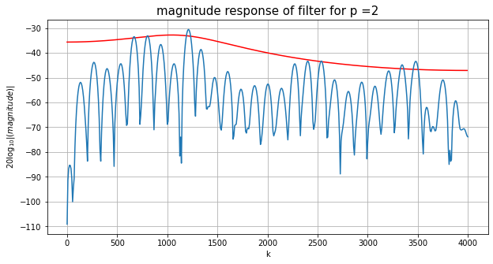

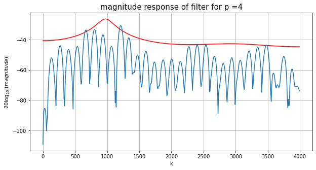

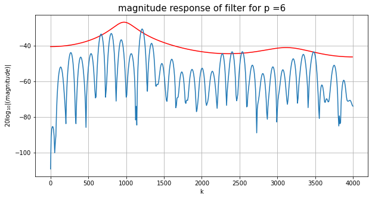

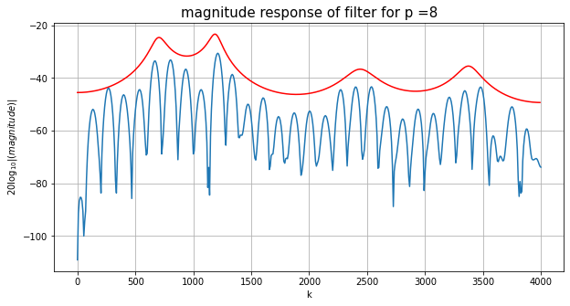

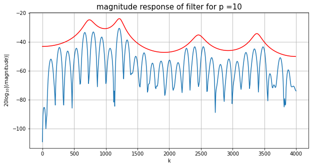

```python
from scipy import signal
def plots(w,h):

  plt.figure(figsize=[10,5])
  plt.plot(w,20*np.log10(np.abs(0.01*h)),'r')

  plt.plot(np.arange(0,(Fs/2)+1,Fs/float(N)),(emph_x-1.5*max(emph_x)))
  plt.title('magnitude response of filter', fontsize=15)
  plt.xlabel('k')
  plt.ylabel('$20\log_{10}|(magnitude)|$')
  plt.grid()

print('Plotting magnitude spectrum for P=[2,4,6,8,10]')


w1, h1 = signal.freqz_zpk(z1, p1, g1, fs=8000)
plots(w1,h1)
plt.title('magnitude response of filter for p =2', fontsize=15)

w2, h2 = signal.freqz_zpk(z2, p2, g2, fs=8000)
plots(w2,h2)
plt.title('magnitude response of filter for p =4', fontsize=15)

w3, h3 = signal.freqz_zpk(z3, p3, g3, fs=8000)
plots(w3,h3)
plt.title('magnitude response of filter for p =6', fontsize=15)

w4, h4 = signal.freqz_zpk(z4, p4, g4, fs=8000)
plots(w4,h4)
plt.title('magnitude response of filter for p =8', fontsize=15)

w5, h5 = signal.freqz_zpk(z5, p5, g5, fs=8000)
plots(w5,h5)
plt.title('magnitude response of filter for p =10', fontsize=15)
```

From the above plots of magnitude response for p = 2,4,6,8 and 10. for p = 2 represents 1 formant frequency therefore in plot it is shown by signal peak.

Also we see that as the order p (i.e no. of pole) increases the estimated response starts following the actual signal enevelope. Therefore for large p Levinson-Durbin recursion approximates STFT analysis.